# draft_talk

## West by Midwest: Package Maintenance, Transition and Handover

*May 14, 2026*

[figure not shown]

[figure not shown]

### Julia Piaskowski

*Director of Statistical Programs, University of Idaho*

### Russ Lenth

*Professor Emeritus of Statistics, University of Iowa*

## Julia Piaskowski has recently taken over maintenance of ‘emmeans’ from Russ Lenth.

### How is that going?

### What challenges have we encountered?

## Emmeans Background

- for estimating marginal means from a linear modeling object
- legacy package: first released November 5, 2017
- replacing ‘lsmeans’ (first released August 15, 2012)
- methods based on Searle, Speed, and Milliken (1980) Population marginal means in the linear model: An alternative to least squares means, *The American Statistician* **34(4)**, 216-221 [doi:10.1080/00031305.1980.10483031](https://doi.org/10.1080%2F00031305.1980.10483031).

# Russ’ Perspective

## West by Midwest: Where we are

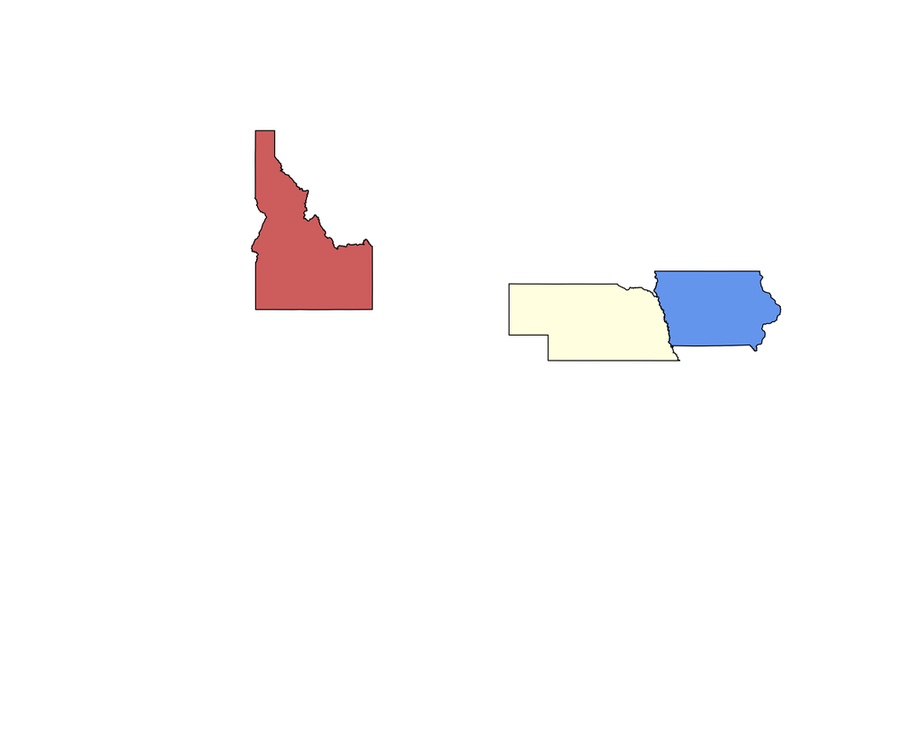

## West by Midwest: Where we’ve lived

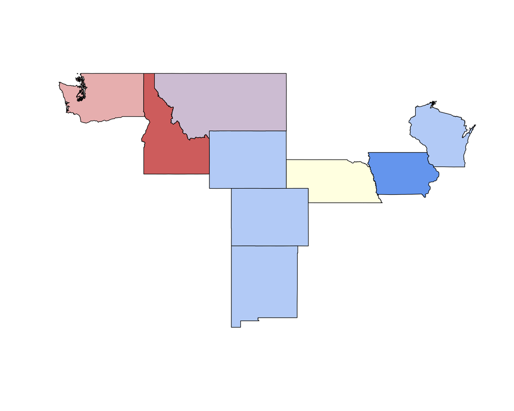

## Russ’s Computing Background

- Skeletran, Fortran IV
- Algorithms for noncentral $F$, beta, and $t$
- Power and sample size
  - Pascal
  - Xlisp-stat
  - Java
- Other R packages: [**rsm**](https://CRAN.R-project.org/package=rsm), [**lsmeans**](https://CRAN.R-project.org/package=lsmeans), [**estimability**](https://CRAN.R-project.org/package=estimability), [**vigindex**](https://github.com/rvlenth/vigindex)

## Origins of ‘lsmeans’

- Preliminary thoughts about how to obtain LSmeans focused on interpretation of model coefficients
  - What to do with covariates?
  - Doesn’t help that SAS Type III estimable functions do this wrong (IMHO)
- Salary equity analysis for administration
  - Focus on what model *predicts*
  - Duh! Those are the linear functions of coefficients that I need

## Differing application perspectives

- LSMs use *equal weighting*
- Makes sense to experimenters
- Others who deal with observational data, not so much
- Alernative weighting: Proportional, Outer, Flat
- Causal effects: *G* computation (counterfactuals)
- Other packages or platforms: Stata, **effects**, **marginaleffects**, **margins**

## emmeans (2017–)

- Re-structure of **lsmeans** with improved architecture and class structure, customizability
- Expanding to generalized linear models, link functions and response transformations
- Version 2.0.3 has 45 source files (17,500 lines)
  - 9,700 lines of R code
  - 7,800 lines of comments or embedded documentation
- 243 functions (79 public), 16 vignettes
- 121 reverse depends/imports/suggests/enhances

## Getting into R package development

- My first package was rsm
- I had existing code that worked, and used `package.skeleton()` function (still available) to bundle it up
  - But this required writing separate `Rd` files, etc.
- Now the way to go is to use RStudio (or Positron) – free download – and create a new project
- Use **roxygen2** package to incorporate documentation, imports, etc.
- Wickham, H and Bryan, J (2023) *R Packages* (2d ed), O’Reilly Media, Inc.

## Observations on package development

- Writing code is fun
- Writing documentation & vignettes is less fun, and time-consuming. But really important
- Your stuff is there for others to see – and they will look

## My pet peeves with some other people’s packages

- Cramped,runtogethercode. Use whitespace
- Over-abstraction. Use meaningful (but short) variable names
- Re-using the same variable or object name in a string of examples

#### Bug reports

- Same peeves, also unnecessary elaboration

## Transition experience

- Julia …
  - encouraged me to add ‘pkgdown’ site (July ’24)
  - set up GitHub action to update site automatically
  - started monitoring the Issues page
  - began answering some issues
  - major overhaul graphics theme
  - took over as official maintainer (August ’25, version 2.0.0)

## Transitioning = Stress of change + Benefits

- ‘pkgdown’ as mentioned before
- Different work habits & availability
- Repo management – working in branches
- Coding style (e.g., I like “`=`” rather than “`<-`”)
  - but similar styles with whitespace and indentation
- Joint responsibility for decisions (e.g., no “stars”)

# Julia’s Perspective

## Programming Background

- Originally trained in SAS
- Started using R in 2010 when I was unable to access all the predictions from `PROC PLS` (SAS v9.3)
- R in those days was hard (no tidyverse, ggplotting, or RStudio), but it had enough functionality and flexibility to make it worth the effort.
- Learned C, python, bash shell scripting. Programming is satisfying!
- I pay attention to the R ecosystem and read source code frequently.

## Programming Philosophy

[output not shown]

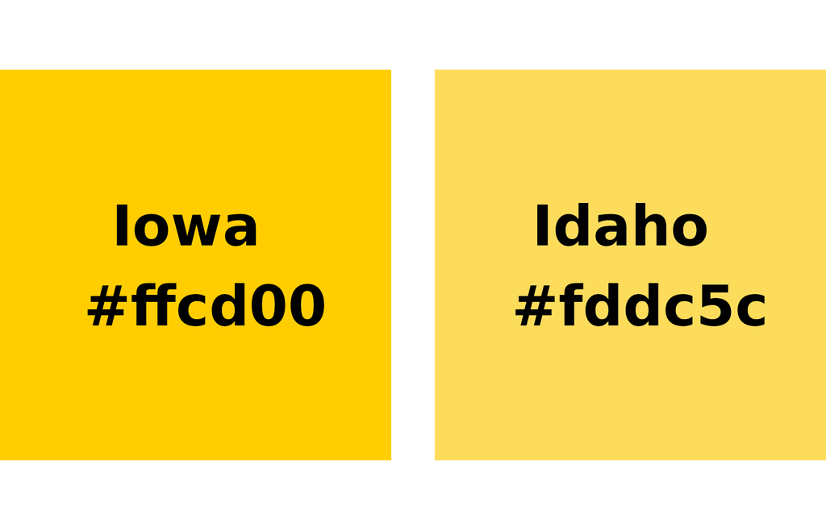

## Why SAS Type III Anova is wrong

*(when covariates are involved)*

```r
library(emmeans)
fiber.add = lm(strength ~ diameter + machine, data = fiber) # why have this?
fiber.int = lm(strength ~ diameter * machine, data = fiber)

emmeans(fiber.add, "machine") |> contrast("consec") |> test(joint = TRUE)
```

```
 df1 df2 F.ratio p.value
   2  11   2.611  0.1181
```

```r
emmeans(fiber.int, "machine") |> contrast("consec") |> test(joint = TRUE)
```

```
 df1 df2 F.ratio p.value
   2   9   2.814  0.1124
```

```r
# What SAS type III ANOVA does
emmeans(fiber.int, "machine", at = list(diameter = 0)) |>
    contrast("consec") |> test(joint = TRUE)
```

```
 df1 df2 F.ratio p.value
   2   9   0.475  0.6367
```

## SAS compares intercepts, not LSmeans

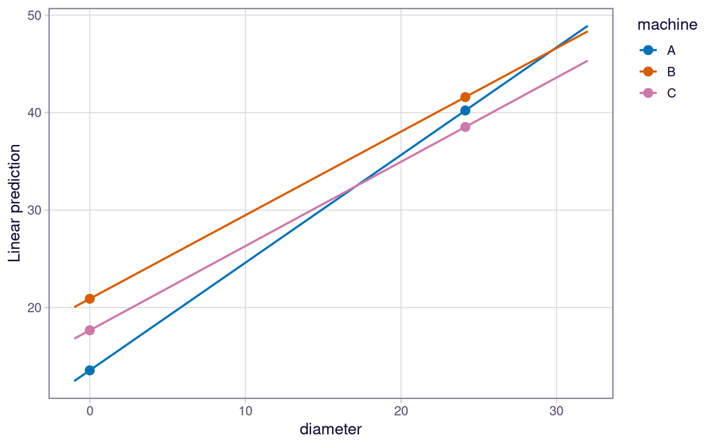

## Confirming SAS’s output

#### With model equivalent to `fiber.int`

```
Source                     DF    Type III SS    Mean Square   F Value   Pr > F
diameter                    1    171.1192314    171.1192314     61.00   <.0001
machine                     2      2.6641625      1.3320812      0.47   0.6367
diameter*machine            2      2.7371774      1.3685887      0.49   0.6293
```

*(`machine` result matches joint test of intercepts)*

#### With `diameter` centered:

```
Source                     DF    Type III SS    Mean Square   F Value   Pr > F
ctr_diam                    1    171.1192314    171.1192314     61.00   <.0001
machine                     2     15.7906794      7.8953397      2.81   0.1124
ctr_diam*machine            2      2.7371774      1.3685887      0.49   0.6293
```

*(`machine` result matches joint test of LSmeans)*

**Lesson**: In SAS, if you have covariates that interact with anything, center (or standardize) them first